# Open and Reproducible Research: Tools 3

January, 2015

## Topics

- Git
- Github
- Reproducible research check list

## What is git?

- the stupid content tracker
- a fast, scalable, distributed revision control system with an unusually rich command set that provides both high-level operations and full access to internals.
- "I'm an egotistical bastard, and I name all my projects after myself. First 'Linux', now 'git'" — Linus Torvalds according to "Why the 'Git' name?" item in GitFaq. Accessed at https://git.wiki.kernel.org/index.php/GitFaq on Jan, 2015.

## Tracking changes of working file(s) over time 1

- versioning

[figure not shown]

- `egsr03.dat`: Egyptian WFS Standard Record Ver 3

## Tracking changes over time 2

- timestamping

[figure not shown]

- `504_ideas_2014-05-19T19_04_52Z_public_cleaned.csv`

## Tracking changes over time 3

- snapshot: state of a system (here a file) at a particular point in time

[figure not shown]

- keep only the latest (current) files in the working directory
- `20141201` directory has the `analysis.Rmd` (and any other files) as was on Dec., 1, 2014
- `20141223` directory has the `anaysis.Rmd` (ditto) as was on Dec., 23, 2014

## More elaborate snapshots strategy

- put all the snapshots under a subdirectory (repo?)
- snapshot names don't have to be date
- "branches" idea

[figure not shown]

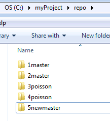

## Git as snapshot management system

- each snapshot is called a 'commit'
- Git stores file contents as well as meta-data (file names, who made the snapshot (commit), when, how this snapshot is related to other snapshot, …)
- Git stores everything under the (hidden) .git directory
- everything in Git is check-summed before it is stored and is then referred to by that checksum (20-byte SHA-1 hash)
- Git generally only adds information – it is hard to get Git do something undoable or to erase/lose data without Git's knowing
- Git is a distributed system – everybody has their own local copy of the entire history of a project

## First-time Setup

- open the cmd.exe (terminal) window
- set name and email

```r
git config --global user.name "Mary Smith"
git config --global user.email msmith@example.edu
```

- set text editor

```r
git config --global core.editor nano
```

## Quiz

Open cmd.exe. Set your global user.name and user.email to your choices; and the core.editor to nano.

Once you've done that, what does the following command returns?

```r
git config --global core.editor
```

1. vim
2. chang y. chung
3. cchung@princeton.edu
4. nano

## Demonstration: Initial commit

- will demonstrate the following:
  - create a project directory
  - create a R Markdown file (analysis.Rmd)
  - test run it using rscript
- open the windows explorer and cmd.exe window and do:
  - `git init`
  - `git add analysis.Rmd`
  - `git commit -m 'commit for the first time'`
  - `git status` to check the status
  - `git log` to view the history (commits)
- try it yourself

## Checking repository status and reviewing project history

- to see where things are at: `git status`
- a new or modified file should be:
  - first staged(cached) using `git add`; and
  - then snapshot by `git commit`
- to see the history (of commits): `git log`

## Quiz

Indicate if the following statement is true or false.

in order to make a snapshot of a new or modified file using Git, we need to get the file:

- first staged (cached) using `git add`; and
- then snapshot by `git commit`

## Challenge

Create an appropriate `makefile`, and then make another commit with a commit message, "add a makefile"

Once done, then the `git log` should show two commits like so:

```r
commit 6b3f0c8bad195b94c99f658b8182a5fa87d1605f
Author: Chang Y. Chung <chang_y_chung@hotmail.com>
Date:   Wed Jan 7 15:20:02 2015 -0500

    add a makefile

commit e7f3e7bc9220fd552cbe03a0bf89436ea8fe157c
Author: Chang Y. Chung <chang_y_chung@hotmail.com>
Date:   Wed Jan 7 15:09:57 2015 -0500

    commit for the first time
```

## Challenge

- practice another commit
  - Open and edit `analysis.Rmd`. Save. Now `git status` reports that `analysis.Rmd` is not staged.
  - Process it by `make` – this will overwrite `analysis.html` if exists. Try `git status` again and confirm that the .Rmd file is not staged and the .html file is not tracked.
  - Issue `git add analysis.*` to stage both the file. Commit with a message, something like "make editorial changes and track html"
- extra
  - Confirm that `git log` now shows three commits.
  - Try options like `git log --oneline`
  - See help using `--help` option like: `git log --help`

## Let's take a break

- any questions?

## See the differences

- Open the analysis.Rmd and make some changes. I am going to add another sentence on top.
- `git diff analysis.Rmd` shows the differences between the latest working version (not staged yet) and that in the latest commit.
- `git diff --help` shows many different comparisons possible

## Undoing

- Commit too early and possibly forget to add some files: `git commit --amend` and example:

```r
git commit -m 'initial commit'

git add some_file_to_add
git commit --amend
```

- Unstaging a staged (`git add`ed) file: `git reset HEAD file_to_unstage`
- You've modified a file and messed it up. Would like to start over how it was at the last commit: `git checkout -- file_to_revert_back` (See demonstration)

## Branching

- a Git repository with three commits and only one (default) branch, master

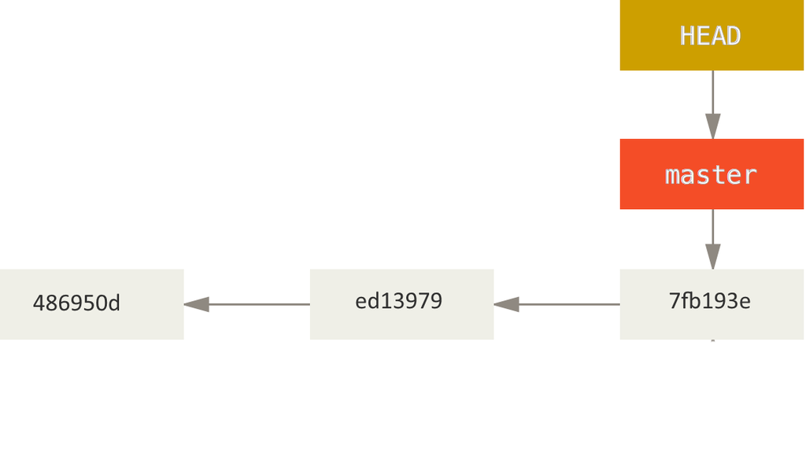

```r
> git log --oneline --decorate
7fb193e (HEAD, master) third commit
ed13979 second commit
486950d first commit
> git branch
* master
```

## Create a branch

- `git branch testing`

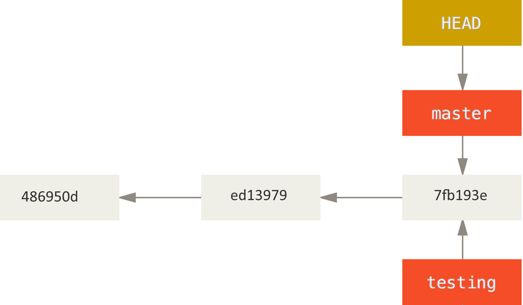

```r
> git branch testing
> git log --oneline --decorate
7fb193e (HEAD, testing, master) third commit
ed13979 second commit
486950d first commit
```